# learnRmd

Michael Dillon

December 7, 2018

# R Markdown

R markdown has three components: `to force the new line, I added 2 spaces at the end`  
1. metadata (between 2 `---` at top of document)  
2. text (of any kind, anywhere)  
3. and code, surrounded by 3 backticks for a code chunk, or a single backtick for inline calculations (2x2=4).

R Markdown syntax is Pandoc Markdown. For help on all the options, check the [pandoc user guide](https://pandoc.org/MANUAL.html).

## Metadata

`note the 3 hashes to make a subheading`

### Basics of YAML

The YAML (“YAML ain’t markup language”) header is picky about formatting, including indentation. Use examples or go to a reference to solve more complicated problems. (see bookdown.org for lots of info). The `keep_md: true` option is nice for hosting on github as the .md renders nicely there.

Can be floating or not, several other options.

### Themes

Specify the theme or set it to null and point to a .css document.

### Figures

Can specify `fig_width`, `fig_height`, `fig_caption`, `dev`.

### data frame output

Set the `df_print` option to: kable, tibble, paged

### Code folding

Can include code, but have it hidden by default by setting html_document, `code_folding: hide`

### Templates

See documentation, but this allows for customization of html, latex, pdf, word, etc. such that the markdown text is rendered to preset formatting guidelines.

## Text

Again, this is the stuff you are writing to either *document* your **analyses** or discuss them (for example, in a paper).

Some help with text: To add an image, use `![**Figure 1**. Nice beetle.](figures/bug.jpeg)`:

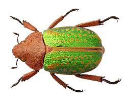

**Figure 1**. Nice beetle.

> “Not everyone likes bugs, but I do.”

> – famous entomologist

Inline latex based equations! $f(k) = \circ p^k 1-p_n + 2$ (And it updates a box showing you the equation in real time!)

## Code

# Compile

Using the knit button or Ctrl-Shift-K.

This renders in a new R session … a very important point because it means that anything in the console from the previous session is now gone. This is a good thing, related to why you shouldn’t save your .Rhistory as it can lead to issues with reproducibility.

You can also render via the command-line or a script, giving you the ability to have automated report generation but you have to worry about reproducibility in that case.

# Shared options

To share options across documents within a directory, include a file named `_output.yml` in the directory (the file will have standard YAML syntax but without the opening and closing `---`). All documents within that directory will then inherit yaml settings from that file, with any specifications in an individual file overriding or adding to those “baseline” specifications.

# PDF output

A bit different because many of the YAML options are top-level rather than underneath the pdf_output line

You can also have includes underneath the pdf_document option, to put bits of tex at the head, before body, and after body sections of a “document”, and you can replace the template with your own template using that option.